# Lecture 05 Exercise — Checking a published LDA paper

PubH 6010 Independent Study · LDA, QDA & naive Bayes

Your name: Katie O’Brien

2026-09-27

# 1 Why this exercise

Lecture 05 introduces a different route to P(Y = g | X = x). Logistic regression and KNN model that probability **directly**. LDA, QDA and naive Bayes model how the predictors are distributed **within each class**, f_g(x), and then use Bayes’ theorem with the class priors π_g to get the posterior (slides 5–7). The three methods differ only in what they assume about f_g(x).

This week’s paper is **not** environmental health. It is a clinical diagnostic study, chosen because it names LDA in its title and uses a public dataset, so you can put your own LDA next to the paper’s. The skill that carries over to your project is checking a methods section against the method: does the paper do what it says LDA does, and can its numbers support its conclusions? This is practice for the article critique due in December.

# 2 The paper and the data

> Adebiyi MO, Arowolo MO, Mshelia MD, Olugbara OO. **Linear discriminant analysis classification model for breast cancer diagnosis.** *Applied Sciences.* 2022;12(22):11455. doi:10.3390/app122211455 (open access)

Read the **Abstract**, **Materials and Methods** (especially the paragraphs on feature scaling and LDA), **Table 1** and the captions of **Figures 2–5** (the confusion matrices).

`wdbc.csv` is the Wisconsin Diagnostic Breast Cancer dataset (Street, Wolberg & Mangasarian 1993), the Kaggle file the paper cites, with column names cleaned (see `data_dictionary.Rmd`). Each row is one fine-needle aspirate (FNA) of a breast mass. Each column summarizes the cell nuclei in a digitized image of that aspirate.

**Outcome:** `diagnosis`, B (benign) or M (malignant). Treat **malignant as the positive class** throughout.

# 3 Your tasks

Use **tidyverse** (`readr`, `dplyr`, `tidyr`, `ggplot2`, `purrr`), `MASS` for `lda()` and `qda()`, and `e1071` for `naiveBayes()` (and `svm()`, provided). Load MASS with `library(MASS, exclude = "select")` so it doesn’t mask `dplyr::select()`. Submit your knitted `.Rmd` with written answers to the questions in **bold**.

## 3.1 Part A — The data and the priors

1. Read `wdbc.csv`, make `diagnosis` a factor with levels `c("B", "M")`, and report the class counts and proportions.
2. Look at the correlations among `radius_mean`, `perimeter_mean`, `area_mean` and `radius_worst`.

```r
library(MASS, exclude = "select")
library(readr); library(dplyr); library(tidyr); library(ggplot2); library(purrr); library(e1071)

# read in data
wdbc <- read_csv("wdbc.csv", show_col_types = FALSE) |>
  mutate(diagnosis = factor(diagnosis, levels = c("B", "M")))
feats <- setdiff(names(wdbc), c("id", "diagnosis"))

# counts and proportions
wdbc %>% count(diagnosis) %>%
  mutate(percent = (n/sum(n))*100)
```

```
## # A tibble: 2 × 3
##   diagnosis     n percent
##   <fct>     <int>   <dbl>
## 1 B           357    62.7
## 2 M           212    37.3
```

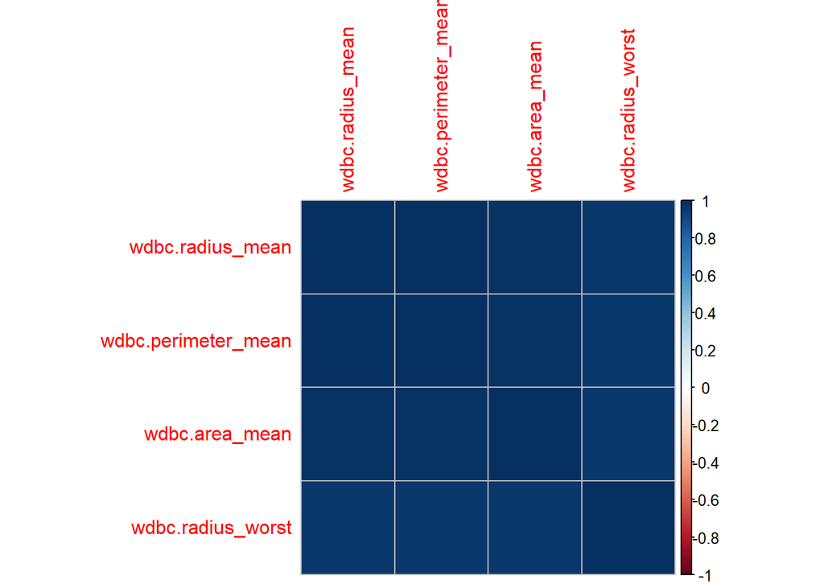

```r
# correlations
vars <-data.frame(wdbc$radius_mean, wdbc$perimeter_mean, wdbc$area_mean, wdbc$radius_worst)
cor_matrix <- cor(vars, use = "complete.obs")
library(corrplot)
corrplot(cor_matrix, method = "square")
```

There are 357 (62.7%) in class B and 212 (37.2%) in class M. The correlations between radius mean, perimeter mean, area mean, and radius worst are close to 1.

> **Q1.** What is π̂_M? Slide 7 says the sample proportion estimates π_g *if we have a random sample*. Where do these 569 aspirates come from, and would π̂_M carry over to other clinics or to screening? Why should radius, perimeter and area be so highly correlated, and which of this week’s three methods will that hurt most?

## 3.2 Part B — The paper’s pipeline

The paper uses an 80/20 split, “feature scaling”, LDA “feature extraction”, then a random forest or SVM. It reports no seed and no cross-validation.

3. Split 80/20 with `set.seed(2026)`. Standardize every feature using the **training** mean and SD.
4. Fit `lda()` on all 30 features. How many discriminant directions (columns of `$scaling`) do you get? List the LD1 coefficients sorted by absolute size.
5. Refit on the **unstandardized** training data and compare the test-set posterior probabilities with those from the standardized fit.

```r
# ---- Part B: the paper's split ----
set.seed(2026)
idx   <- sample(nrow(wdbc), round(0.8 * nrow(wdbc)))
train <- wdbc[idx, ]; test <- wdbc[-idx, ]
# training has 455 features and test data has 114 features
sum(train$diagnosis == "M")
```

```
## [1] 174
```

```r
# 174 malignant cases in training data
sum(test$diagnosis == "M")
```

```
## [1] 38
```

```r
# 38 malignant cases in test data

ctr <- map_dbl(train[feats], mean); scl <- map_dbl(train[feats], sd)
standardize <- \(df) mutate(df, across(all_of(feats), \(v) (v - ctr[cur_column()]) / scl[cur_column()]))
train_s <- standardize(train); test_s <- standardize(test)

# on standardized data
f_all   <- reformulate(feats, response = "diagnosis")
lda_fit <- lda(f_all, data = train_s)
dim(lda_fit$scaling)
```

```
## [1] 30  1
```

```r
# scaling is 30 x 1

# to get the posterior probabilities
pred <- predict(lda_fit, newdata = test_s)

# refitting on unstandardized training data
lda_fit_2 <- lda(f_all, data = train)
dim(lda_fit$scaling)
```

```
## [1] 30  1
```

```r
pred_2 <- predict(lda_fit_2, newdata = test)

# comparison of posterior probabilities
prob_df <- data.frame(
  actual = test$diagnosis,
  standardized_model = pred$posterior,
  unstandardized_model = pred_2$posterior
)

head(prob_df)
```

```
##   actual standardized_model.B standardized_model.M unstandardized_model.B
## 1      M         4.801458e-05         9.999520e-01           4.801458e-05
## 2      M         4.171341e-03         9.958287e-01           4.171341e-03
## 3      M         9.294055e-05         9.999071e-01           9.294055e-05
## 4      B         9.999156e-01         8.439486e-05           9.999156e-01
## 5      M         8.823023e-05         9.999118e-01           8.823023e-05
## 6      M         2.178643e-04         9.997821e-01           2.178643e-04
##   unstandardized_model.M
## 1           9.999520e-01
## 2           9.958287e-01
## 3           9.999071e-01
## 4           8.439486e-05
## 5           9.999118e-01
## 6           9.997821e-01
```

> **Q2.** How many discriminant directions can LDA produce with G classes (compare slide 19, where G = 3)? The paper says LDA “dropped ten (10) least important columns”. Is that something LDA does? Could sorting |LD1| coefficients be a sensible way to rank features here? Look at which features top the list, and at their signs. Did “feature scaling” change your LDA at all? For which methods in this course *does* scaling matter?

LDA can produce G-1 discriminant directions. LDA does not drop the least important columns, so the paper’s description is incorrect. It also does not rank features. Feature scaling does not change the LDA model. Scaling matters for KNN, clustering, and PCA.

## 3.3 Part C — LDA, QDA, naive Bayes and logistic regression

6. On the same split, fit `qda()`, `naiveBayes()` and `glm(..., family = binomial())` with all 30 features, plus the provided `svm()`. For each, report correct/114, accuracy, sensitivity and specificity **for malignant**, and the confusion counts.
7. Count the parameters each of LDA, QDA and naive Bayes estimates (slide 24’s formulas), and compare with the number of malignant cases in the training set.
8. Read the warnings from `glm()` and look at its coefficient table.
9. For each model, what share of the test posteriors are below 0.001 or above 0.999?

```r
# ---- Part C ----
qda_fit <- qda(f_all, data = train_s)
nb_fit  <- naiveBayes(f_all, data = train_s)
glm_fit <- glm(f_all, family = binomial(), data = train_s)
svm_fit <- svm(f_all, data = train_s)              # provided: the paper's comparator

probs <- tibble(
  y     = test_s$diagnosis,
  LDA   = predict(lda_fit, test_s)$posterior[, "M"],
  QDA   = predict(qda_fit, test_s)$posterior[, "M"],
  NB    = predict(nb_fit,  test_s, type = "raw")[, "M"],
  Logit = predict(glm_fit, test_s, type = "response"))

# Provided: metrics with malignant as the positive class
metrics_m <- function(y, yhat_M) {
  pos <- y == "M"
  tibble(correct = sum(yhat_M == pos), accuracy = mean(yhat_M == pos),
         sens_M = sum(yhat_M & pos) / sum(pos), spec_M = sum(!yhat_M & !pos) / sum(!pos),
         TP = sum(yhat_M & pos), FN = sum(!yhat_M & pos), FP = sum(yhat_M & !pos), TN = sum(!yhat_M & !pos))
}
probs |> pivot_longer(-y, names_to = "model", values_to = "p") |>
  group_by(model) |> group_modify(\(d, k) metrics_m(d$y, d$p > 0.5))
```

```
## # A tibble: 4 × 9
## # Groups:   model [4]
##   model correct accuracy sens_M spec_M    TP    FN    FP    TN
##   <chr>   <int>    <dbl>  <dbl>  <dbl> <int> <int> <int> <int>
## 1 LDA       110    0.965  0.921  0.987    35     3     1    75
## 2 Logit     111    0.974  0.947  0.987    36     2     1    75
## 3 NB        110    0.965  0.947  0.974    36     2     2    74
## 4 QDA       110    0.965  0.947  0.974    36     2     2    74
```

```r
# counting parameters
p <- length(all.vars(f_all)) - 1
K <- length(unique(train_s$diagnosis))
n_malignant <- sum(train_s$diagnosis == "M")

n_param_lda <- (K - 1) + (K * p) + (p * (p + 1) / 2)
n_param_qda <- (K - 1) + (K * p) + K * (p * (p + 1) / 2)
n_param_nb  <- (K - 1) + (2 * K * p)

param_comparison <- tibble(
  model = c("LDA", "QDA", "NB"),
  n_parameters = c(n_param_lda, n_param_qda, n_param_nb),
  n_malignant_train = n_malignant,
  param_to_malignant_ratio = round(n_parameters / n_malignant, 2)
)

print(param_comparison)
```

```
## # A tibble: 3 × 4
##   model n_parameters n_malignant_train param_to_malignant_ratio
##   <chr>        <dbl>             <int>                    <dbl>
## 1 LDA            526               174                     3.02
## 2 QDA            991               174                     5.7
## 3 NB             121               174                     0.7
```

```r
# extreme values
probs %>%
  summarize(across(c(LDA, QDA, NB, Logit),
                   ~ mean(.x < 0.001 | .x > 0.999))) %>%
  pivot_longer(everything(), names_to = "model", values_to = "extreme_share") %>%
  mutate(percentage = extreme_share*100)
```

```
## # A tibble: 4 × 3
##   model extreme_share percentage
##   <chr>         <dbl>      <dbl>
## 1 LDA           0.544       54.4
## 2 QDA           0.947       94.7
## 3 NB            0.947       94.7
## 4 Logit         0.991       99.1
```

> **Q3.** Can this single test set of 114 cases tell the methods apart? Is QDA’s covariance estimate trustworthy with this many parameters per malignant case? What happened to logistic regression, and which reason on slide 5 does it illustrate? How would you fix it without switching to LDA?

I do not think 114 cases is enough to separate the methods substantially. QDA’s covariance estimate is not trustworthy because there are too many parameters. Logistic regression is unstable because there is too much separation between the classes. I would fix it without switching to LDA by using a larger sample size.

> **Q4.** Naive Bayes assumes the predictors are independent **within each class** (slide 27). How badly do these data violate that? It still classifies well, so where does the damage show up? Why might QDA’s probabilities be extreme too, for a different reason?

The data violate the assumption that the predictors are independent within each class. The damage shows up when there is high bias, because the method introduces some bias to decrease variance. QDA’s probabilities might be extreme as well because the number of training observations is small.